```python
from IPython.display import HTML

HTML('''<script>
code_show=true;
function code_toggle() {
 if (code_show){
 $('div.input').hide();
 } else {
 $('div.input').show();
 }
 code_show = !code_show
}
$( document ).ready(code_toggle);
</script>
<form action="javascript:code_toggle()"><input type="submit" value="Show Python code"></form>''')
```

```python
import prep as p
import matplotlib.pyplot as plt
import pandas as pd
from sklearn.metrics import mean_absolute_error
```

# Predicting Professional Soccer Player's Wages

## By: Anuraag Polisetty, Anant Rajeev, Hari Kaushik, Kyle Wistrand

## INFO 370 Final Resource

## March 13th, 2019

### Variable Analysis:

After downloading our data set, we realized that we had to clean our data set before being able to analyze any of it. The data set that we used had variables that we wanted to use that were not in number form. We went about enumerating a lot of the columns. Some of the columns that underwent this process were “Offensive Workrate”, “Defensive Workrate”, “Nationality”, and “Position”. These variables, we deemed, all had innate value and potential impact on the wage, so we had to change these variables from strings into numbers, so that we could actually run a statistical analysis on them and use them to develop our model. Fundamentally, we wanted to use the game-set player statistics in our model. Since each player had ratings for several different gameplay attributes as well as one overall rating, we decided to add up the several attributes into one big rating and keep the overall rating as well. That way, we were able to get the player’s overall ability instead of developing our model using each individual rating. This would be a better reflection of the club’s interests in determining wage based on a player’s overall ability. The driving force behind all of our data cleaning and feature extraction was asking ourselves if this particular task would help us determine the best predictor variables for the models we intended to build.

```python
# Data Preparation and Cleaning
df = p.prepared_df()
df.head()
```

|  | ID | Age | Nationality | Overall | Potential | Club | International Reputation | Weak Foot | Skill Moves | Jersey Number | ... | Inches | num_position | enum_d_work_rate | enum_o_work_rate | norm_wage | norm_value | total_stats | power_foot_num | Days_at_Club | enum_weights |
| --- | --- | --- | --- | --- | --- | --- | --- | --- | --- | --- | --- | --- | --- | --- | --- | --- | --- | --- | --- | --- | --- |
| 0 | 158023 | 31 | Argentina | 94 | 94 | FC Barcelona | 5.0 | 4.0 | 4.0 | 10.0 | ... | 67 | 3 | 1 | 1 | 565.0 | 110500.0 | 2244.0 | 1 | 5366 | 159 |
| 1 | 20801 | 33 | Portugal | 94 | 94 | Juventus | 5.0 | 4.0 | 5.0 | 7.0 | ... | 74 | 3 | 0 | 2 | 405.0 | 77000.0 | 2265.0 | 0 | 244 | 183 |
| 2 | 190871 | 26 | Brazil | 92 | 93 | Paris Saint-Germain | 5.0 | 5.0 | 5.0 | 10.0 | ... | 69 | 3 | 1 | 2 | 290.0 | 118500.0 | 2178.0 | 0 | 585 | 150 |
| 3 | 193080 | 27 | Spain | 91 | 93 | Manchester United | 4.0 | 3.0 | 1.0 | 1.0 | ... | 76 | 0 | 1 | 1 | 260.0 | 72000.0 | 2220.0 | 0 | 2810 | 168 |
| 4 | 192985 | 27 | Belgium | 91 | 92 | Manchester City | 4.0 | 5.0 | 4.0 | 7.0 | ... | 71 | 2 | 2 | 2 | 355.0 | 102000.0 | 2313.0 | 0 | 1289 | 154 |

5 rows × 54 columns

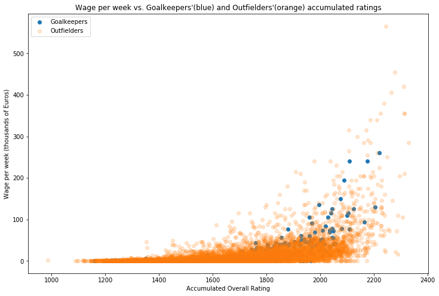

```python
plt.figure(figsize=(12,8))
goalkeepers = df[df.num_position == 0]
fielders = df[df.num_position != 0]
plt.scatter(goalkeepers['total_stats'], goalkeepers['norm_wage'], label = "Goalkeepers")
plt.scatter(fielders['total_stats'], fielders['norm_wage'], alpha=.2, label = "Outfielders")
plt.title("Wage per week vs. Goalkeepers'(blue) and Outfielders'(orange) accumulated ratings")
plt.xlabel("Accumulated Overall Rating")
plt.ylabel("Wage per week (thousands of Euros)")
plt.legend()
```

### Plot 1:

The first visualization we created was the player’s overall accumulated rating that we calculated on the x-axis as the independent variable, with that player’s wage per week on the y-axis as the dependent variable. Ideally, we would expect to see close to a 1-to-1 correlation, with wage being offered linearly to accumulated rating. It seemed reasonable to assume that the higher a person’s rating, the higher they would be paid. We decided that it would be fair to color-code the scatter plot, having the blue data points correspond to goalkeeper data points and the orange data points correspond to the outfielder data points (defenders, midfielders, and forwards). We made this decision because goalkeepers inherently have lower overall statistics as their ability as goalkeepers is judged on lower weights than that of outfield players. To normalize the goalkeeping ratings, we multiplied each of our goalkeeper accumulated ratings by a constant, 5. We calculated 5 because that was, on average, the factor by which the goalkeeper accumulated ratings were less than the outfielder accumulated ratings.

This graph resembled that of a logistic growth with the only true rises in wage offerings being visible after the statistical rating increased to roughly 2000 for both the goalkeepers and the outfielders. What this plot ended up telling us is that regardless of how high a person’s overall rating is, the club will likely look at the strength of particular attributes in a player to determine wage until this point. At a 2000 rating, the player is likely overall very solid which would lead them to have a higher salary, which is what our graph displays.

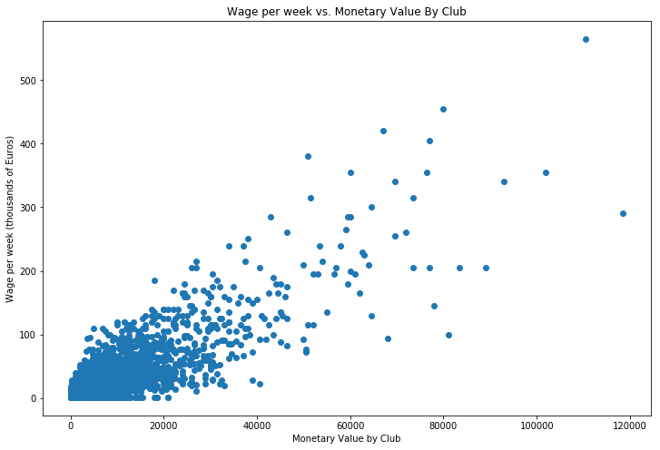

```python
plt.figure(figsize=(12,8))
plt.scatter(df['norm_value'], df['norm_wage'])
plt.title("Wage per week vs. Monetary Value By Club")
plt.xlabel("Monetary Value by Club")
plt.ylabel("Wage per week (thousands of Euros)")
```

### Plot 2:

Our second visualization showcases how much monetary value the club puts on the player on the x-axis as the independent variable and the player’s wage per week on the y-axis as the dependent variable. To make our data more manageable and our graph scaled more appropriately, we decided to record both the value and wage as thousands-of-dollars (originally they were in millions). What we expected to see again was a 1-to-1 correlation with the monetary value and the wage per week. We believed that teams place a value on a particular player in accordance with the wage that they pay them per week.

After displaying the scatter plot, what we found was closer to our expectations than our first plot was. We observed the data in the scatter plot taking more of a linear form, but with a large cluster in the bottom left side of the graph. This cluster corresponded to a monetary value of €0-€20M and a weekly wage of €0-€100,000. Past this cluster, we could start to see more of a linear plot being developed, with a few outliers either above or below the 1-to-1 line. This plot is more of what we expected, as we would ideally see that clubs pay their players in accordance to the value that they place on them.

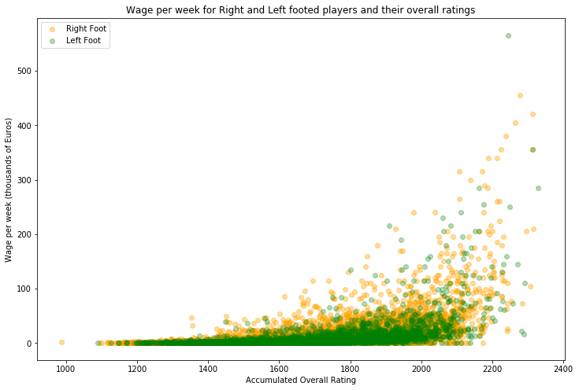

```python
plt.figure(figsize=(12,8))
right = df[df.power_foot_num == 0]
left = df[df.power_foot_num == 1]
plt.scatter(right['total_stats'], right['norm_wage'],color='orange', alpha=.4, label='Right Foot')
plt.scatter(left['total_stats'], left['norm_wage'],color='green', alpha=.3, label='Left Foot')
plt.title("Wage per week for Right and Left footed players and their overall ratings")
plt.xlabel("Accumulated Overall Rating")
plt.ylabel("Wage per week (thousands of Euros)")
plt.legend()
```

### Plot 3:

Our third visualization is a slight variation of our first plot. In this visualization we wanted to separate the players by preferred foot and then see how those specific overall ratings were potentially correlated with player wage per week. Conveniently, our data set included the player’s preferred foot as an attribute. This was a variable of interest for us, so to use it in our models and plots, we had to enumerate it. The number “0” signified that that particular player was right-footed and the number “1” signified that the player was left-footed. Our plot had the player’s accumulated overall rating on the x-axis as the independent variable and the player’s wage per week on the y-axis as the dependent variable. The plot was color-coded accordingly with the orange data points representing the right-footed players and the green data points representing the left-footed players.

This time around, we expected to see the left footed and right footed data points having a similar shape being shown on the graph as our first visualization, which was essentially a logistic growth once the accumulated overall rating went up to a certain level. However, if the shapes of both the colored points weren’t the same, we could have used our plot to expose a certain unknown trend that clubs use when deciding a player’s wage. We didn’t expect the shape to change much and wanted to prove that clubs don’t necessarily evaluate the player’s preferred foot as a factor in determining their wage. As we expected, the shape of the plot for both left and right-footed players stayed very similar to a logistic growth, and it happened at around the same accumulated rating that we observed in our first visualization (2000).

# Model Scatter Plots

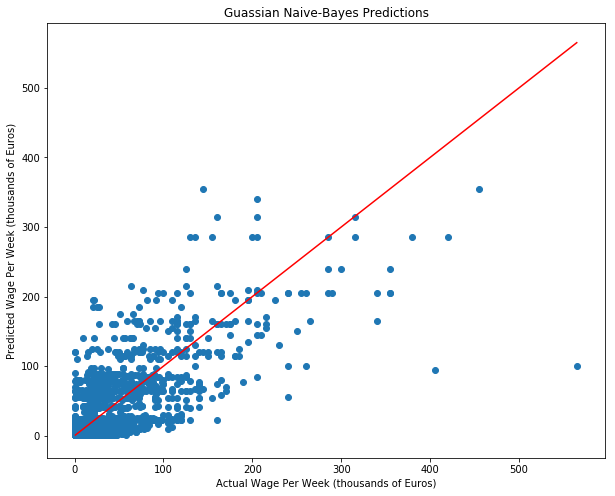

```python
## GAUSSIAN NAIVE BAYES
data = pd.read_csv('./model_predictions/GaussianNB.csv')
plt.figure(figsize=(10,8))
lineStart = data['norm_wage'].min()
lineEnd = data['norm_wage'].max()
plt.plot([lineStart, lineEnd], [lineStart, lineEnd], 'k-', color = 'red')
plt.scatter(data['norm_wage'], data['0'])
plt.title("Guassian Naive-Bayes Predictions")
plt.xlabel("Actual Wage Per Week (thousands of Euros)")
plt.ylabel("Predicted Wage Per Week (thousands of Euros)")
```

```python
data.fillna(value=0, inplace=True)
print("Mean absolute error: " + str(mean_absolute_error(data['norm_wage'],data['0'])))
```

```
Mean absolute error: 5.802389816260358
```

### Gaussian Naive-Bayes Regressor:

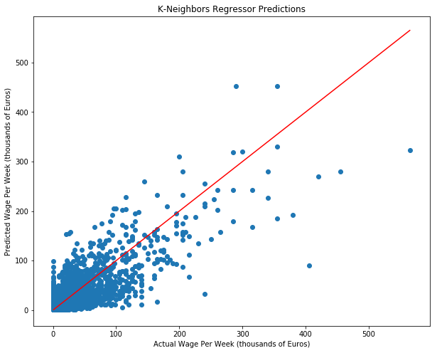

```python
### K Nearest Neighbors
data = pd.read_csv('./model_predictions/KNeighborsRegressor.csv')
plt.figure(figsize=(10,8))
lineStart = data['norm_wage'].min()
lineEnd = data['norm_wage'].max()
plt.plot([lineStart, lineEnd], [lineStart, lineEnd], 'k-', color = 'red')
plt.scatter(data['norm_wage'], data['0'])
plt.title("K-Neighbors Regressor Predictions")
plt.xlabel("Actual Wage Per Week (thousands of Euros)")
plt.ylabel("Predicted Wage Per Week (thousands of Euros)")
```

```python
data.fillna(value=0, inplace=True)
print("Mean absolute error: " + str(mean_absolute_error(data['norm_wage'],data['0'])))
```

```
Mean absolute error: 5.320838837516512
```

### K-Nearest-Neighbors Regressor:

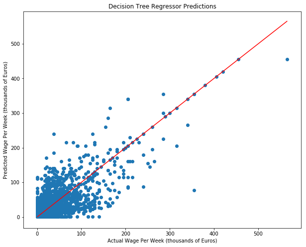

```python
# Decision Tree Regressor
data = pd.read_csv('./model_predictions/DecisionTreeRegressor.csv')
plt.figure(figsize=(10,8))
lineStart = data['norm_wage'].min()
lineEnd = data['norm_wage'].max()
plt.plot([lineStart, lineEnd], [lineStart, lineEnd], 'k-', color = 'red')
plt.scatter(data['norm_wage'], data['0'])
plt.title("Decision Tree Regressor Predictions")
plt.xlabel("Actual Wage Per Week (thousands of Euros)")
plt.ylabel("Predicted Wage Per Week (thousands of Euros)")
```

```python
data.fillna(value=0, inplace=True)
print("Mean absolute error: " + str(mean_absolute_error(data['norm_wage'],data['0'])))
```

```
Mean absolute error: 5.871802569953164
```

### Decision Tree Regressor:

The third model we ran as a predictive model on our data set was the singular decision tree regressor. After running our model, we calculated the Decision Tree model’s mean absolute error to be 5.8718. This value corresponded to our model being, on average, €5,871.80 either above or below the actual value. Out of the five models that we ran on this data set, this model’s mean absolute error was the highest, corresponding to it being the least accurate model that we ran. Upon observing the scatter plot, we observed 1 noticeable outlier that trended in a completely different direction than the rest of our data.

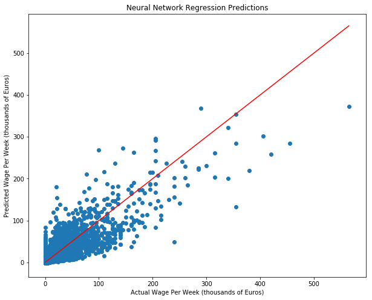

```python
data = pd.read_csv('./model_predictions/MLPRegressor.csv')
plt.figure(figsize=(10,8))
lineStart = data['norm_wage'].min()
lineEnd = data['norm_wage'].max()
plt.plot([lineStart, lineEnd], [lineStart, lineEnd], 'k-', color = 'red')
plt.scatter(data['norm_wage'], data['0'])
plt.title("Neural Network Regression Predictions")
plt.xlabel("Actual Wage Per Week (thousands of Euros)")
plt.ylabel("Predicted Wage Per Week (thousands of Euros)")
```

```python
data.fillna(value=0, inplace=True)
print("Mean absolute error: " + str(mean_absolute_error(data['norm_wage'],data['0'])))
```

```
Mean absolute error: 4.881568012768382
```

### Neural Network Regressor:

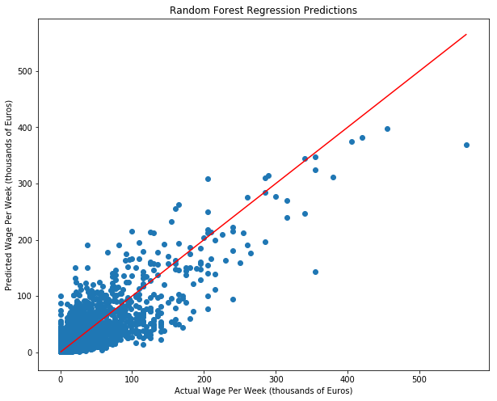

```python
data = pd.read_csv('./model_predictions/RandomForestRegressor.csv')
plt.figure(figsize=(10,8))
lineStart = data['norm_wage'].min()
lineEnd = data['norm_wage'].max()
plt.plot([lineStart, lineEnd], [lineStart, lineEnd], 'k-', color = 'red')
plt.scatter(data['norm_wage'], data['0'])
plt.title("Random Forest Regression Predictions")
plt.xlabel("Actual Wage Per Week (thousands of Euros)")
plt.ylabel("Predicted Wage Per Week (thousands of Euros)")
```

```python
data.fillna(value=0, inplace=True)
print("Mean absolute error: " + str(mean_absolute_error(data['norm_wage'],data['0'])))
```

```
Mean absolute error: 5.052629398342741
```

### Random Forest Regressor:

The fifth model we ran to predict wages was the Random Forest regression. This algorithm essentially is the aggregation of many decision trees. After running our model, we calculated the Random Forest model’s mean absolute error to be 5.0526. This value corresponded to our model’s predictions being on average €5,052.6 either above or below the actual wage value. Out of the five models that we ran on this data set, this model’s mean absolute error was the second lowest, corresponding to it being the second most accurate model that we ran. Upon observing the scatter plot, we noticed about 2 very noticeable outliers that were much lower than the 1:1 line we included.